# Advanced ggplot graphics

2018.19 MICB405

Dr. Kim Dill-McFarland

version November 06, 2018

# Overview

Thus far in this module, we have explored and transformed data as well as created relatively simple plots using the tidyverse in R. But there is so much more that ggplot (and R) can do!

To help you in your projects, here are some other very useful tools for customizing plots from the tidyverse including

- Faceting
- Multi-panel figures

# Setup

You should open your `introR` R project and **continue** working in your `ggplot.R` script. Remember to rerun the lines to load packages and now **add** the cowplot package.

Load packages  
**R v3.4 or newer**

```r
library(tidyverse)
library(cowplot)
```

**R v3.3 or older**

```r
library(readr)
library(dplyr)
library(tidyr)
library(ggplot2)
library(cowplot)
```

And load and clean the raw data *if you did not save your R project last time*.

```r
raw_dat <- read_csv("Saanich_Data.csv")
```

```r
dat <-
  raw_dat %>%
  select(Cruise, Date, Depth, Temperature,
         WS_O2, WS_NO3, WS_H2S) %>%
  filter(!is.na(WS_O2)) %>%
  rename(O2_uM=WS_O2, NO3_uM=WS_NO3, H2S_uM=WS_H2S) %>%
  mutate(Depth_m=Depth*1000)
```

# Facetting

Rather than putting a lot of information into a single graphic, we can split the graphic into panels by certain features. This is called faceting.

Let’s return to this plot.

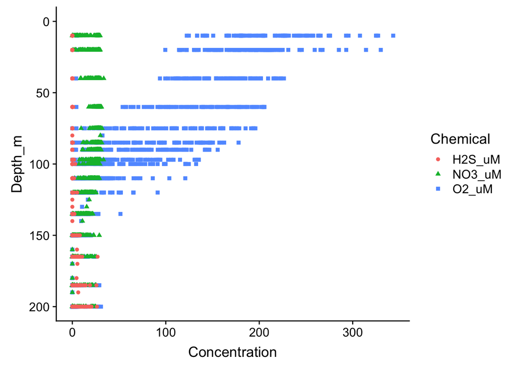

```r
dat %>%
  select(Depth_m, O2_uM, NO3_uM, H2S_uM) %>%
  gather(key="Chemical", value="Concentration", -Depth_m) %>%

  ggplot(aes(x=Concentration, y=Depth_m, shape=Chemical, color=Chemical)) +
  geom_point() +
  scale_y_reverse(limits=c(200, 0))
```

Many of our data points overlap so we may want to separate the geochemical variables into separate plots. Instead of independently creating 3 plots, we can instead add `facet_wrap` of the Chemical variable to the exact same code from above.

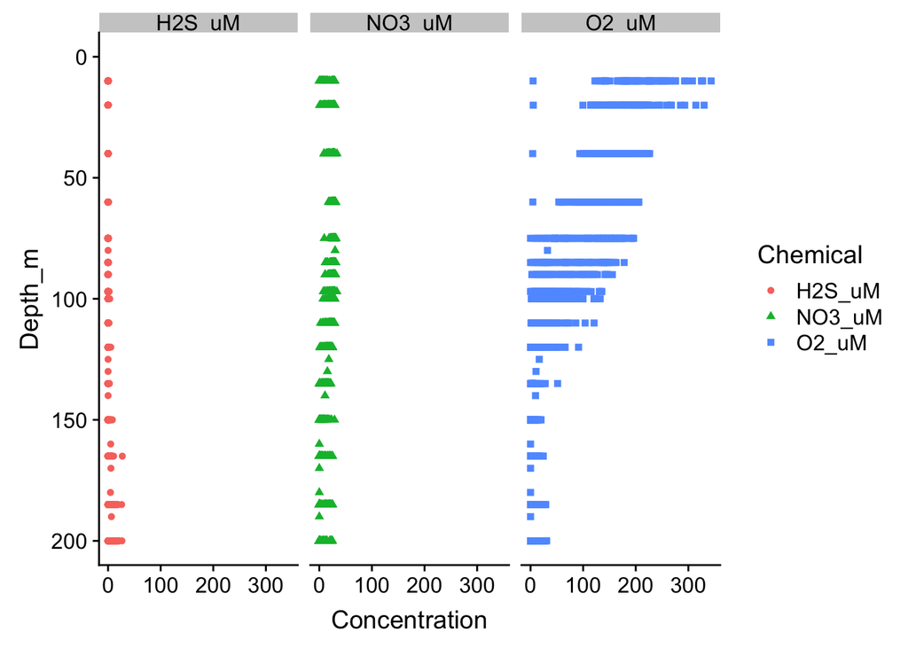

```r
dat %>%
  select(Depth_m, O2_uM, NO3_uM, H2S_uM) %>%
  gather(key="Chemical", value="Concentration", -Depth_m) %>%

  ggplot(aes(x=Concentration, y=Depth_m, shape=Chemical, color=Chemical)) +
  geom_point() +
  scale_y_reverse(limits=c(200, 0)) +
  facet_wrap(~Chemical)
```

Since the 3 variables are on somewhat different scales, we can also tell ggplot to scale the x-axes independently within each facet with the `scales` option.

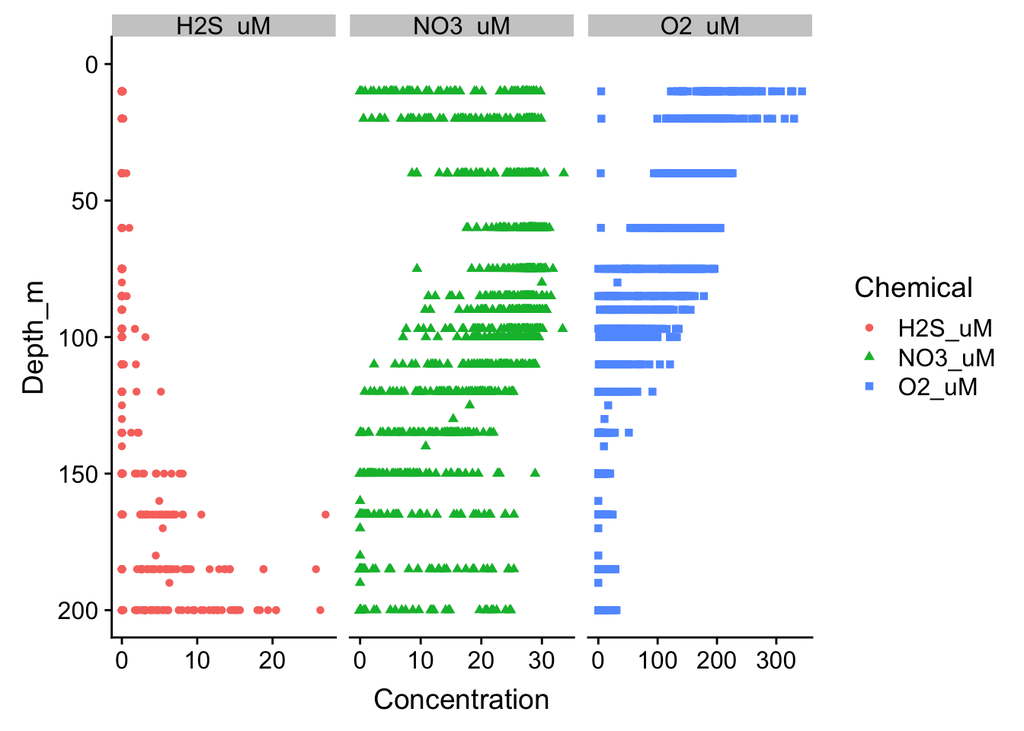

```r
dat %>%
  select(Depth_m, O2_uM, NO3_uM, H2S_uM) %>%
  gather(key="Chemical", value="Concentration", -Depth_m) %>%

  ggplot(aes(x=Concentration, y=Depth_m, shape=Chemical, color=Chemical)) +
  geom_point() +
  scale_y_reverse(limits=c(200, 0)) +
  facet_wrap(~Chemical, scales="free_x")
```

You can also facet across multiple variables using `facet_grid`.

#### Exercise: Facets

We saw in previous analyses that oxygen and nitrate might have a relationship. But we’ve also seen that depth and many compounds are related. So, how might we tease apart this plot from earlier?

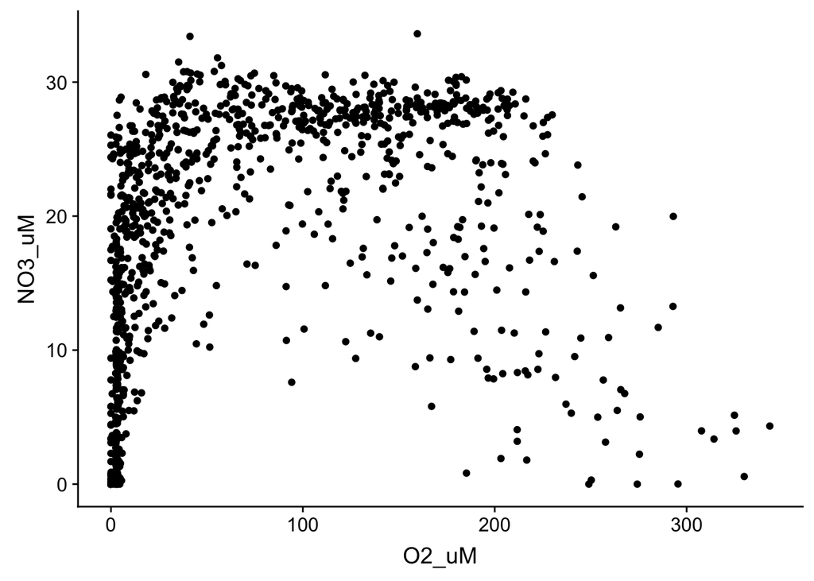

In the following exercise, investigate if depth contributes to the relationship between oxygen and nitrate. We will look at only a couple of depths to simplify the plot.

1. Filter to data to depths 10, 60, 100 and 200 m
2. Plot Oxygen vs Nitrate faceted by Depth

The result should be the following

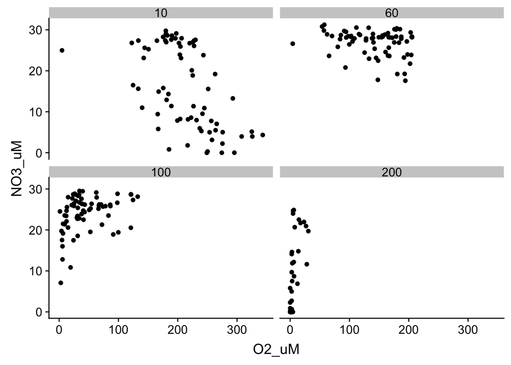

# Themes

By default, ggplot uses a gray color scheme. However, there are a number of other themes that come with ggplot as well as many more in the additional package ggthemes. You can see many examples from [ggplot](https://datascienceplus.com/ggplot2-themes-examples/) or [ggthemes](http://www.rpubs.com/Mentors_Ubiqum/ggthemes_1).

Themes are simply added as another layer in ggplot.

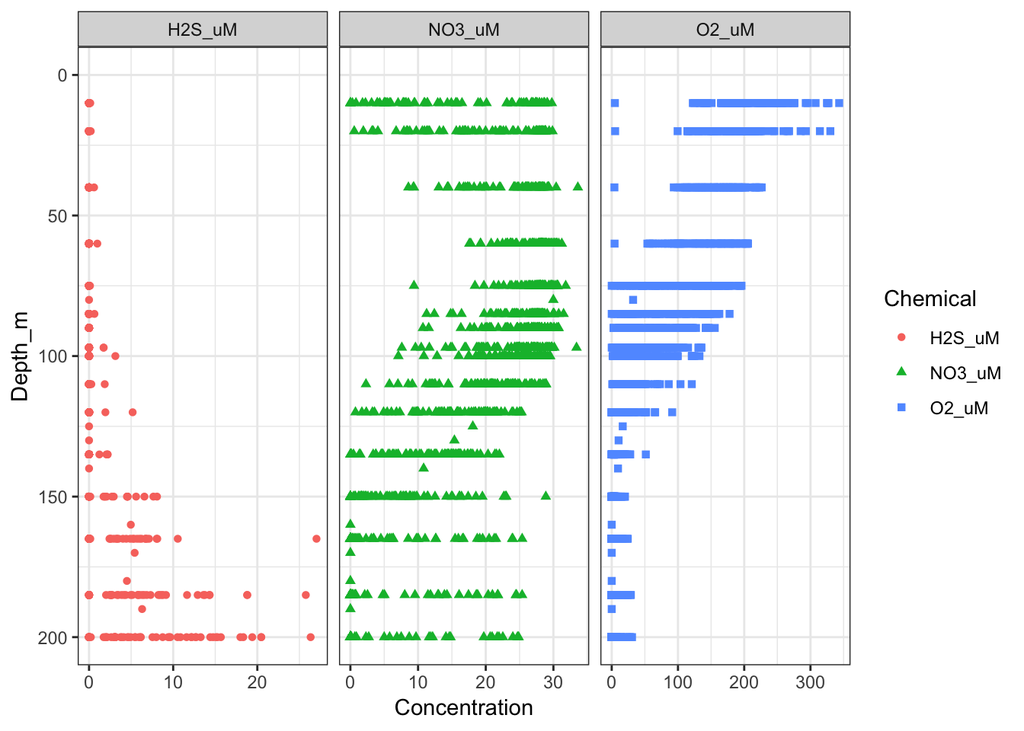

```r
dat %>%
  select(Depth_m, O2_uM, NO3_uM, H2S_uM) %>%
  gather(key="Chemical", value="Concentration", -Depth_m) %>%

  ggplot(aes(x=Concentration, y=Depth_m, shape=Chemical, color=Chemical)) +
  geom_point() +
  scale_y_reverse(limits=c(200, 0)) +
  facet_wrap(~Chemical, scales="free_x") +
  theme_bw()
```

Or you can customize each aspect of your theme (either on its own or in addition to a premade theme) within `theme`. Here, we will only remove the color legend but you can explore many other options with `?theme`.

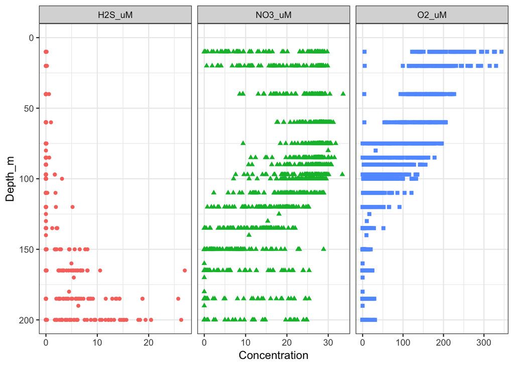

```r
dat %>%
  select(Depth_m, O2_uM, NO3_uM, H2S_uM) %>%
  gather(key="Chemical", value="Concentration", -Depth_m) %>%

  ggplot(aes(x=Concentration, y=Depth_m, shape=Chemical, color=Chemical)) +
  geom_point() +
  scale_y_reverse(limits=c(200, 0)) +
  facet_wrap(~Chemical, scales="free_x") +
  theme_bw() +
  theme(legend.position="none")
```

# Multiple panels

Faceting often gets you the multi-panel figure that you want. But sometimes you may want to combine multiple plot types, plots from different data sets, or perform some other sort of plotting that faceting does not support. Such plots can be achieved by a number of methods both inside and outside R. Here, we will show you one method using the cowplot package

First, we save the plots to be combined as R objects. Let’s use our last plot from above and clean up the labels a bit.

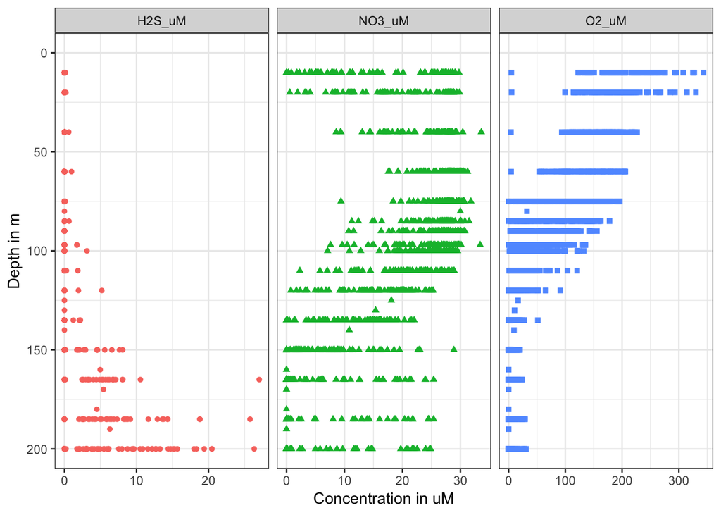

```r
p1 <- dat %>%
  select(Depth_m, O2_uM, NO3_uM, H2S_uM) %>%
  gather(key="Chemical", value="Concentration", -Depth_m) %>%

  ggplot(aes(x=Concentration, y=Depth_m, shape=Chemical, color=Chemical)) +
  geom_point() +
  scale_y_reverse(limits=c(200, 0)) +
  facet_wrap(~Chemical, scales="free_x") +
  theme_bw() +
  theme(legend.position="none") +
  labs(y="Depth in m", x="Concentration in uM")

p1
```

As well as one showing the number of samples obtained at each depth.

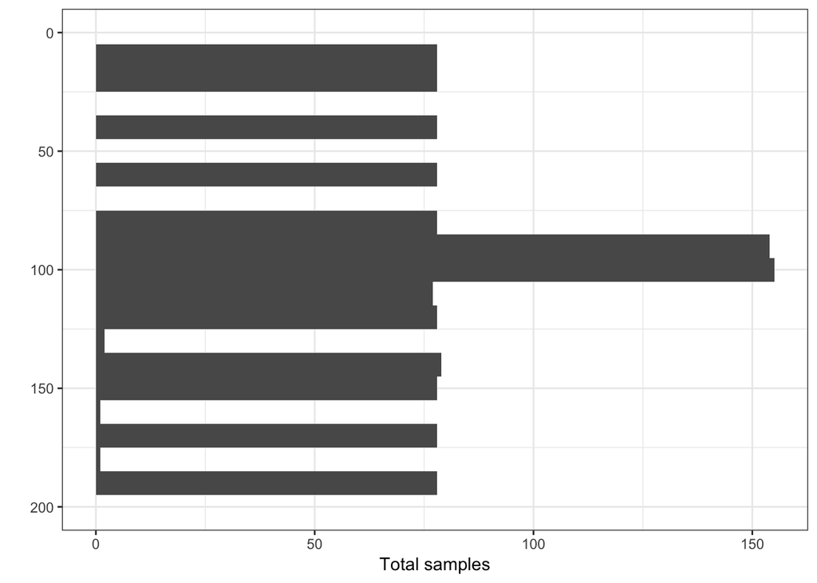

```r
p2 <- dat %>%
  ggplot(aes(x=Depth_m)) +
  geom_histogram(binwidth=10) +
  scale_x_reverse(limits=c(200, 0)) +
  labs(x="", y="Total samples") +
  coord_flip() + # flip the x and y axes
  theme_bw()

p2
```

We can then combine these plots with `plot_grid`. This function allows us to add panel labels, align the edges of plots, line up the axes, determine size (all shown below), and so much more!

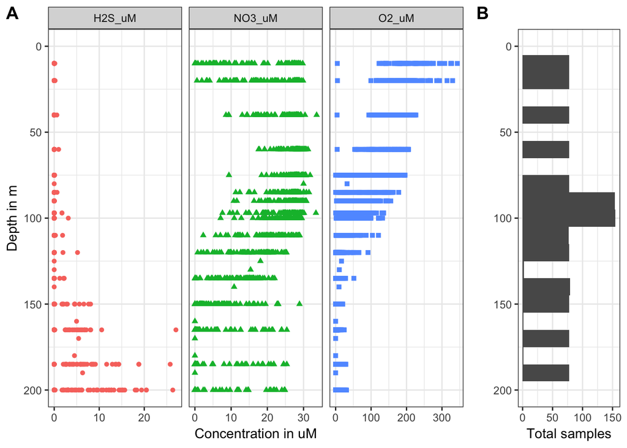

```r
p <- plot_grid(p1, p2, labels=c("A", "B"), align="h", axis="tb", rel_widths=c(3/4, 1/4))

p
```

# Saving ggplots

Using `ggsave` you can save your ggplots to many different file types just by changing the extension in the file name.

Let’s save our ggplot to the projects folder as a pdf.

```r
ggsave("saanich.pdf", p, width=10, height=6)
```

*And sometimes after all this, it’s still not perfect. So, don’t feel bad if you need to finalize plots for publication in another editor like Illustrator. Sometimes it’s a necessary evil.*

# Additional resources

- [R cheatsheets](https://www.rstudio.com/resources/cheatsheets/) also available in RStudio under Help > Cheatsheets
- [ggplot tutorial 1](http://r-statistics.co/Complete-Ggplot2-Tutorial-Part1-With-R-Code.html)
- [ggplot tutorial 2](https://rpubs.com/g_jw/ggplot2_tutorial)
- [ggplot tutorial 3](http://tutorials.iq.harvard.edu/R/Rgraphics/Rgraphics.html#the_1_faq)